CONTENT  
- Motivation  
- Example Single dummy variable  
- Linear Probability Model  
- Logit model  
- Summary

Econometrics

Designed by Professor Sasha Shapoval

for New Uzbekistan University

OLS Further Issues Dummy variables Heteroskedasticity

⚖️ Dummy variables in regressions

# Motivation

To understand why dummy variables are essential in regression models, consider two simple artificial data-generating processes. In both cases, the outcome variable $y$ follows a linear pattern, but an underlying categorical factor changes the behavior of the model. Without explicitly including that factor in the regression, the model cannot capture the true structure of the data.

⚖️ 🧩 Example 1

1. Model:

$$ y = \beta_0 + \beta_1 x + \varepsilon $$

but the intercept $\beta_0$ takes two distinct values. In the real-world, this behavior can caused by differences between men and women, distinct geographical locations, and other binary characteristics.

2. The true relationship between $y$ and $x$ consists of two parallel lines with the same slope $\beta_1$, but with different vertical shifts.
3. If we fit a simple linear regression without acknowledging the two intercepts, the model is forced to estimate a single intercept. As a result, it averages the two groups and misrepresents both.
4. Let's construct a numerical example, altering the intercept between two values with the probability of $1/2$.

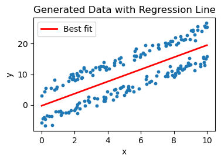

```python
import numpy as np
import pandas as pd
import matplotlib.pyplot as plt
import statsmodels.formula.api as smf

# Parameters
b = 2
intercept1 = -5
intercept2 = 5
ndata = 200

# Generate data
x = np.random.uniform(0, 10, ndata)
group = np.random.randint(0, 2, ndata)
intercepts = np.where(group == 1, intercept1, intercept2)
y = b * x + intercepts + np.random.normal(size=ndata)

# Build dataframe
df_artificial = pd.DataFrame({
    "x": x,
    "y": y,
    "group": group
})

# Fit regression on THIS dataset
reg = smf.ols("y ~ x", data=df_artificial).fit()

# Plot
plt.figure(figsize=(4, 2.5))
plt.scatter(df_artificial["x"], df_artificial["y"], s=10)

# Best-fit line
x_vals = np.linspace(df_artificial["x"].min(), df_artificial["x"].max(), 200)
y_pred = reg.predict(pd.DataFrame({"x": x_vals}))

plt.plot(x_vals, y_pred, color="red", linewidth=2, label="Best fit")
plt.xlabel("x")
plt.ylabel("y")
plt.title("Generated Data with Regression Line")
plt.legend()
plt.show()
```

**Solution**:

$$ y = \beta_0 + \beta_1 x + {\color{red}{\gamma D}} + u $$

where $D$ is a dummy that equals 1 for group A and 0 for group B.

```
Estimated intercept for group = 0: 4.864341567224376
Estimated intercept for group = 1: -5.219580205077164
```

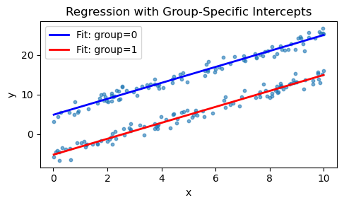

```python
import numpy as np
import pandas as pd
import matplotlib.pyplot as plt
import statsmodels.formula.api as smf

# Fit the model with group shift
reg = smf.ols("y ~ x + group", data=df_artificial).fit()

# Extract intercepts
intercept_0 = reg.params["Intercept"] #group is 0 in the regression
intercept_1 = reg.params["Intercept"] + reg.params["group"] #group is 1

print("Estimated intercept for group = 0:", intercept_0)
print("Estimated intercept for group = 1:", intercept_1)

# Create prediction grid
x_vals = np.linspace(df_artificial["x"].min(), df_artificial["x"].max(), 200)

# Predict for group = 0 and group = 1
pred_0 = reg.predict(pd.DataFrame({"x": x_vals, "group": 0}))
pred_1 = reg.predict(pd.DataFrame({"x": x_vals, "group": 1}))

# Plot data
plt.figure(figsize=(5, 3))
plt.scatter(df_artificial["x"], df_artificial["y"], s=10, alpha=0.6)

# Plot fitted lines
plt.plot(x_vals, pred_0, color="blue", linewidth=2, label="Fit: group=0")
plt.plot(x_vals, pred_1, color="red", linewidth=2, label="Fit: group=1")

plt.xlabel("x")
plt.ylabel("y")
plt.title("Regression with Group-Specific Intercepts")
plt.legend()
plt.tight_layout()
plt.show()
```

```python
reg.params
```

```
Intercept     4.864342
x             2.013711
group       -10.083922
dtype: float64
```

**Info:** Statsmodels estimates:

Intercept → intercept for group = 0

group coefficient → how much to add to the intercept when group = 1

So:

\begin{gather*} \mathrm{intercept}_0 = \beta_0 \\ \mathrm{intercept}_0 = \beta_0 + \gamma \end{gather*}

**Question: Interpret the coefficient $\beta_{\text{group}}$ in the regression**

It represents the predicted change in the intercept for points in group $A$ (where the dummy variable `group` is $1$) relative to points in group $B$

⚖️ Example 2

$$ y = \beta_0 + \beta_1 x + u $$

but in this scenario it is the slope $\beta_1$ that changes between two values

**Solution**:

$$ y = \beta_0 + \beta_1 x + {\color{red}{\gamma (D \cdot x)}} + u $$

- we need a dummy variable,
- this time we must also allow for an interaction between the dummy and the explanatory variable:

Dummy variable

- estimates different slopes ($\beta_1$ or $\beta_1 + \gamma$) through interaction terms,

**Question: Suggest a model with dummy variables when both the intercept and slope differ from group to group**

$y = \beta_0 + \beta_1 x + {\color{red}{\gamma_1 D + \gamma_2 (D \cdot x)}} + u$

- $D = 0$ then $y = \beta_0 + \beta_1 x$
- $D = 1$ then $y = (\beta_0 + \gamma_1) + (\beta_1 + \gamma_2) x$

```
          x  D          y
0  0.037226  1  -5.691553
1  6.432030  1  16.226986
2  9.789542  1  23.275078
3  6.980044  1  15.818406
4  9.437447  1  22.666386
```

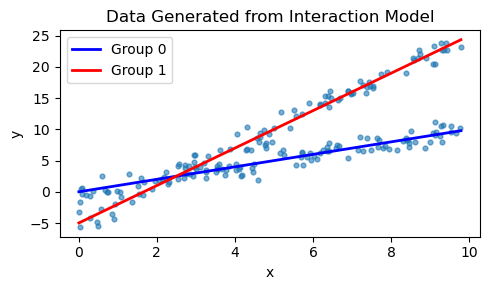

```python
#illustration of a simple regression with dummy terms
#both intercept and slope differ from group to group
import numpy as np
import pandas as pd
import matplotlib.pyplot as plt

# ----------------------------
# Parameters
# ----------------------------
beta0 = 0
beta1 = 1          # change to -1 for the alternative case
gamma1 = -5        # intercept shift
gamma2 = 2         # slope difference
ndata  = 200

# ----------------------------
# Generate data
# ----------------------------
x = np.random.uniform(0, 10, ndata)
D = np.random.randint(0, 2, ndata)   # 0 or 1

# Model:
# y = beta0 + beta1*x + gamma1*D + gamma2*(D*x) + u
u = np.random.normal(size=ndata)

y = beta0 + beta1 * x + gamma1 * D + gamma2 * (D * x) + u

# Build dataframe
df_model = pd.DataFrame({
    "x": x,
    "D": D,
    "y": y
})

print(df_model.head())

# ----------------------------
# Plot data and group-wise fits
# ----------------------------
plt.figure(figsize=(5, 3))
plt.scatter(df_model["x"], df_model["y"], s=12, alpha=0.6)

# Predicted lines
x_vals = np.linspace(df_model["x"].min(), df_model["x"].max(), 200)

# group = 0: y = beta0 + beta1*x
y_pred0 = beta0 + beta1 * x_vals

# group = 1: y = beta0 + beta1*x + gamma1 + gamma2*x
y_pred1 = beta0 + gamma1 + (beta1 + gamma2) * x_vals

plt.plot(x_vals, y_pred0, color="blue", linewidth=2, label="Group 0")
plt.plot(x_vals, y_pred1, color="red",  linewidth=2, label="Group 1")

plt.xlabel("x")
plt.ylabel("y")
plt.legend()
plt.title("Data Generated from Interaction Model")
plt.tight_layout()
plt.show()
```

```python
import statsmodels.formula.api as smf

# Fit the interaction model
reg_int = smf.ols("y ~ x + D + x:D", data=df_model).fit()
# Extract coefficients
beta1  = reg_int.params["x"]
gamma2 = reg_int.params["x:D"]

# Slopes for each group
slope_group0 = beta1
slope_group1 = beta1 + gamma2

print("\n--- Slopes Found ---")
print(f"Slope for group 0: {slope_group0:.4f}")
print(f"Slope for group 1: {slope_group1:.4f}")
```

```
--- Slopes Found ---
Slope for group 0: 1.0352
Slope for group 1: 3.0037
```

✅ Interpretation of the Slopes

**Info:** In the interaction model

$$ y = \beta_0 + \beta_1 x + \gamma_1 D + \gamma_2 (D \cdot x) + u, $$

the estimated coefficient on `x` represents the slope for **group 0**.  
The coefficient on the interaction term `Dx` represents the **difference in slope** between group 1 and group 0.

Thus, $\gamma_2$ tells us how much the slope changes when moving from group 0 to group 1.

```python
#Function formatting the regression outcome; already appeared in the multiple regression notebook
def format_regression_output(results):
    """
    Print a statsmodels OLS regression in Stata-style:
    - Model equation with coefficients
    - Coefficients with standard errors underneath
    - t-statistics and p-values
    - Number of observations, SSR, and R-squared
    """

    params = results.params
    ses = results.bse
    t_stats = results.tvalues
    p_values = results.pvalues
    dep_var = results.model.endog_names

    # ----- Build regression equation -----
    eq = f"{dep_var} = "

    # Intercept first (if present)
    if "Intercept" in params.index:
        eq += f"{params['Intercept']:.4f}"
    else:
        eq += "0"

    # Add other variables
    for var in params.index:
        if var == "Intercept":
            continue
        sign = "+" if params[var] >= 0 else "-"
        eq += f" {sign} {abs(params[var]):.4f}*{var}"

    # ----- Print equation -----
    print("Model equation:\n")
    print("  " + eq + "\n")

    # ----- Print coefficients + SEs + t-statistics + p-values -----
    print("Coefficients (standard errors in parentheses, t-statistics and p-values in brackets):\n")
    for var in params.index:
        print(f"{var:12} {params[var]: .4f}")
        print(f"{'':12} ({ses[var]:.4f}) [t={t_stats[var]:.3f}, p={p_values[var]:.3f}]")
    print()

    # ----- Print model statistics -----
    n = int(results.nobs)
    ssr = float((results.resid ** 2).sum())
    r2 = float(results.rsquared)

    print(f"Number of observations (n): {n}")
    print(f"Sum of squared residuals (SSR): {ssr:.4f}")
    print(f"R-squared: {r2:.4f}\n")
```

# Example Single dummy variable

Wage example from the Wooldrdige handbook

```python
import wooldridge as woo
import numpy as np
import statsmodels.formula.api as smf
wage1 = woo.dataWoo('wage1')
reg = smf.ols(formula= 'wage ~ female + educ + exper + tenure', data=wage1)
results = reg.fit()
format_regression_output(results)
```

```
Model equation:

  wage = -1.5679 - 1.8109*female + 0.5715*educ + 0.0254*exper + 0.1410*tenure

Coefficients (standard errors in parentheses, t-statistics and p-values in brackets):

Intercept    -1.5679
             (0.7246) [t=-2.164, p=0.031]
female       -1.8109
             (0.2648) [t=-6.838, p=0.000]
educ          0.5715
             (0.0493) [t=11.584, p=0.000]
exper         0.0254
             (0.0116) [t=2.195, p=0.029]
tenure        0.1410
             (0.0212) [t=6.663, p=0.000]

Number of observations (n): 526
Sum of squared residuals (SSR): 4557.3077
R-squared: 0.3635
```

**Question: Interpret the coefficient -1.8109 ahead of $\mathtt{female}$**

Holding education, experience, and tenure constant, women earn on average $\$1.81$ less per hour than men.

**Next step: Regression with the dependent variable $\log(\mathrm{wage})$ as the dependent variable**

- More computational technique from the Heiss & Brunner handbook

```python
import wooldridge as woo
import numpy as np
import statsmodels.stats.outliers_influence as smo
import patsy as pt

wage1 = woo.dataWoo('wage1')
# extract matrices using patsy:
y, X = pt.dmatrices('np.log(wage) ~ educ + exper + tenure', data=wage1, return_type='dataframe')
# get VIF:
K = X.shape[1]
VIF = np.empty(K)
for i in range(K):
    VIF[i] = smo.variance_inflation_factor(X.values, i)
print(f'VIF: \n{VIF}\n')
```

```
VIF:
[29.37890286  1.11277075  1.47761777  1.34929556]
```

**Explanation: What does `pt.dmatrices` do?**

`patsy.dmatrices()` takes a model formula (written in **R-style syntax**) and a DataFrame, and then:

1. **Parses the formula** into a *response variable* (`y`) and a *design matrix* of regressors (`X`).
2. **Applies all formula operations** (e.g., `+`, `*`, interaction terms, polynomial terms, `C()` for categories, etc.).
3. **Returns** the resulting `y` and `X` **as matrices or DataFrames** (here, because `return_type='dataframe'`, you get pandas DataFrames).

So the line:

```
y, X = pt.dmatrices('np.log(wage) ~ educ + exper + tenure', data=wage1, return_type='dataframe')
```

create the dependent variable `log(wage)` and the matrix of independent variables (`intercept`, `educ`, `exper`, `tenure`).

**What does `smo.variance_inflation_factor` do?**

`variance_inflation_factor()` computes the **Variance Inflation Factor (VIF)** for a specific regressor in the design matrix.

For each column `i` in the matrix `X`, VIF is defined as:

$$ \text{VIF}_i = \frac{1}{1 - R_i^2}, $$

where $ R_i^2 $ is the R-squared from a regression of $ X_i $ on all the *other* columns of `X`.

Interpretation:

- **VIF = 1** — no multicollinearity
- **VIF between 1 and 5** — mild to moderate multicollinearity
- **VIF > 10** — high multicollinearity (often considered problematic)

Thus, in the loop:

```
for i in range(K):
    VIF[i] = smo.variance_inflation_factor(X.values, i)
```

each regressor (including the intercept) is evaluated for how strongly it is linearly related to the others.

**Back to `smf.ols()`**

```python
import wooldridge as woo
import numpy as np
import statsmodels.formula.api as smf
wage1 = woo.dataWoo('wage1')
reg = smf.ols(formula= 'np.log(wage) ~ female + educ + exper + I(exper**2) + tenure + I(tenure**2)', data=wage1)
results = reg.fit()
format_regression_output(results)
```

```
Model equation:

  np.log(wage) = 0.4167 - 0.2965*female + 0.0802*educ + 0.0294*exper - 0.0006*I(exper ** 2) + 0.0317*tenure - 0.0006*I(tenure ** 2)

Coefficients (standard errors in parentheses, t-statistics and p-values in brackets):

Intercept     0.4167
             (0.0989) [t=4.212, p=0.000]
female       -0.2965
             (0.0358) [t=-8.281, p=0.000]
educ          0.0802
             (0.0068) [t=11.868, p=0.000]
exper         0.0294
             (0.0050) [t=5.916, p=0.000]
I(exper ** 2) -0.0006
             (0.0001) [t=-5.431, p=0.000]
tenure        0.0317
             (0.0068) [t=4.633, p=0.000]
I(tenure ** 2) -0.0006
             (0.0002) [t=-2.493, p=0.013]

Number of observations (n): 526
Sum of squared residuals (SSR): 82.9506
R-squared: 0.4408
```

**Question: Interpret coefficient on `female` Comment on effect of education Describe a marginal effect of experience**

- Because the dependent variable is in logs, this coefficient can be interpreted approximately as a **percentage difference**: Women earn about $ 100 \times (e^{-0.2965} - 1) \approx -25.6\% $ **less** than comparable men, holding education, experience, and tenure fixed.
- In a log–linear model, this means that **each additional year of schooling** increases hourly wages by approximately $ 100 \times 0.0802 \approx 8.02\% $.
- The marginal effect (in percentage terms) is $\frac{\partial \ln(wage)}{\partial\ exper} = 0.0294 -0.0012\,exper.$  
  This means:
  1. low experience, the effect is positive
  2. As experience increases, the return decreases
  3. Returns become zero at $ 0.0294 - 0.0012\,exper = 0 \quad\Rightarrow\quad exper = 24.5 $. After roughly 25 years of experience, the wage–experience profile peaks.

🧩 Cross-dependence

```python
import wooldridge as woo
import numpy as np
import statsmodels.formula.api as smf
wage1 = woo.dataWoo('wage1')
reg = smf.ols(formula= 'np.log(wage) ~ female + married + I(female*married)', data=wage1)
results = reg.fit()
format_regression_output(results)
```

```
Model equation:

  np.log(wage) = 1.5208 - 0.1316*female + 0.4267*married - 0.3748*I(female * married)

Coefficients (standard errors in parentheses, t-statistics and p-values in brackets):

Intercept     1.5208
             (0.0510) [t=29.827, p=0.000]
female       -0.1316
             (0.0668) [t=-1.971, p=0.049]
married       0.4267
             (0.0616) [t=6.932, p=0.000]
I(female * married) -0.3748
             (0.0857) [t=-4.373, p=0.000]

Number of observations (n): 526
Sum of squared residuals (SSR): 116.7056
R-squared: 0.2132
```

**Technical notes**

Cleaner to write

```
reg = smf.ols(formula= 'np.log(wage) ~ female * married', data=wage1)
```

because `female * married` automatically expands to `female + married + female:married`

```python
import wooldridge as woo
import numpy as np
import statsmodels.formula.api as smf
wage1 = woo.dataWoo('wage1')
reg = smf.ols(formula= 'np.log(wage) ~ female * married', data=wage1)
results = reg.fit()
format_regression_output(results)
```

```
Model equation:

  np.log(wage) = 1.5208 - 0.1316*female + 0.4267*married - 0.3748*female:married

Coefficients (standard errors in parentheses, t-statistics and p-values in brackets):

Intercept     1.5208
             (0.0510) [t=29.827, p=0.000]
female       -0.1316
             (0.0668) [t=-1.971, p=0.049]
married       0.4267
             (0.0616) [t=6.932, p=0.000]
female:married -0.3748
             (0.0857) [t=-4.373, p=0.000]

Number of observations (n): 526
Sum of squared residuals (SSR): 116.7056
R-squared: 0.2132
```

**Question: what a group does correspond to setting `female` = 0 and `married` = 0 How can we find the intercept for married men? How can we test that the null hypothesis that the gender differential does not depend on marital status**

$\newcommand{\Exp}{\operatorname{E}}$ $\newcommand{\Var}{\operatorname{Var}}$ $\newcommand{\Prob}[1]{\mathtt{P}{#1}}$

# Linear Probability Model

In the linear probability model (LPM), the dependent variable $y$ is binary, and the regression model is

$$ y_i = \beta_0 + \beta_1 x_{i1} + \beta_2 x_{i2} + \cdots + \beta_k x_{ik} + u_i. $$$$ \Exp(y \mid x) = \beta_0 + \beta_1 x_{i1} + \beta_2 x_{i2} + \cdots + \beta_k x_{ik}. $$$$ \Prob(y=1 \mid x) = \beta_0 + \beta_1 x_{i1} + \beta_2 x_{i2} + \cdots + \beta_k x_{ik}. $$

$1 - \beta_0 - \beta_1 x_{i1} - \beta_2 x_{i2} - \cdots - \beta_k x_{ik}$

🧩 Interpretation: Example

$$ \mathtt{inlf} = \beta_0 + \beta_1\mathtt{nwifeinc} + \beta_2\mathtt{educ} + \beta_3\mathtt{exper} + \beta_4\mathtt{exper}^2 + \beta_5\mathtt{age} + \beta_6\mathtt{kidslt6} + \beta_7\mathtt{kidsge6} + u $$

| **Variable** | **Description** |
| --- | --- |
| `inlf` | Binary variable for labor-force participation: $inlf = 1$ if the married woman worked for a wage at any time in 1975, $0$ otherwise. |
| `nwifeinc` | Non-wife income: husband’s earnings, measured in thousands of dollars. Represents other household income sources. |
| `educ` | Years of education completed by the woman. |
| `exper` | Past labor-market experience (in years). |
| `age` | Age of the woman (in years). |
| `kidslt6` | Number of children in the household younger than 6 years old. |
| `kidsge6` | Number of children between ages 6 and 18. |

```python
import wooldridge as woo
import pandas as pd
import statsmodels.formula.api as smf
from regres import format_regression_output
mroz = woo.dataWoo('mroz')
# estimate linear probability model:
reg_lin = smf.ols(formula='inlf ~ nwifeinc + educ + exper + I(exper**2) + age + kidslt6 + kidsge6', data=mroz)
results = reg_lin.fit() #results = reg_lin.fit(cov_type='HC3')

#---adding the parent directory to sys.path
import sys
import os
parent_dir = os.path.abspath(os.path.join(os.getcwd(), '..', 'lib'))
if parent_dir not in sys.path:
    sys.path.insert(0, parent_dir)
#---Done
format_regression_output(results)
```

```
Model equation:

  inlf = 0.5855 - 0.0034*nwifeinc + 0.0380*educ + 0.0395*exper - 0.0006*I(exper ** 2) - 0.0161*age - 0.2618*kidslt6 + 0.0130*kidsge6

Coefficients (standard errors in parentheses, t-statistics and p-values in brackets):

Intercept     0.5855
             (0.1542) [t=3.798, p=0.000]
nwifeinc     -0.0034
             (0.0014) [t=-2.351, p=0.019]
educ          0.0380
             (0.0074) [t=5.151, p=0.000]
exper         0.0395
             (0.0057) [t=6.962, p=0.000]
I(exper ** 2) -0.0006
             (0.0002) [t=-3.227, p=0.001]
age          -0.0161
             (0.0025) [t=-6.476, p=0.000]
kidslt6      -0.2618
             (0.0335) [t=-7.814, p=0.000]
kidsge6       0.0130
             (0.0132) [t=0.986, p=0.324]

Number of observations (n): 753
Sum of squared residuals (SSR): 135.9197
R-squared: 0.2642
```

$$ \mathtt{inlf} = 0.5855 - 0.0034\mathtt{nwifeinc} + 0.0380\mathtt{educ} + 0.0395\mathtt{exper} - 0.0006\mathtt{exper}^{2} - 0.0161\mathtt{age} - 0.2618\mathtt{kidslt6} + 0.0130\mathtt{kidsge6} $$

**Question: Interpret an increase in the number of children in the household younger than 6 years old by $4$.**

Everything else equal, the probability that the married woman worked decreases by $0.2618 \cdot 4 > 1$, which is impossible

⚠️ **Warning:** Shortcomings: probabilities lying outside the $[0, 1]$ interval:

- because linear model is incorrect
- can still describe the response variable will within the range of available data

**Question: What an assumption of the Gauss-Markov theorem is violated in this model**

This violates the homoscedasticity assumption because the variance $\Var{u \mid x_i} = p_i (1-p_i)$, where $p_i = \Prob{(y_i = 1 \mid x_i)} = x_i \beta$. In particular, because of this the usual OLS $t$-statistics are not valid

Testing the Hypothesis $H_0: \beta_1 = 0$ against the two-sided alternative

To test the hypothesis

$$ H_0: \beta_1 = 0 \quad \text{vs} \quad H_1: \beta_1 \ne 0, $$

you must use **heteroskedasticity-robust standard errors** (HC0, HC1, HC2, or HC3).  
With robust standard errors, OLS is still consistent and inference is valid.

The robust $t$-statistic is:

$$ t = \frac{\hat{\beta}_1}{\text{SE}_{\text{robust}}(\hat{\beta}_1)}. $$

The two-sided p-value is:

$$ p = 2 (1 - F_{t}(|t|)), $$

where $F_t$ is the appropriate reference distribution (asymptotically standard normal when sample size is large).

**Notes**

- You **cannot** use regular OLS standard errors.
- You **can** test hypotheses using robust standard errors.
- Alternatively, you may estimate a nonlinear model (logit/probit), but this is not required to test $\beta_1 = 0$ in the LPM.

🔹 Example: **Does a married woman's education significantly increase her probability of participating in the labor force?**

Let's use the above dataset to answer the question

1. Statistical Hypotheses

Null hypothesis:

$$ H_0 : \beta_2 = 0 $$

Alternative hypothesis:

$$ H_1 : \beta_2 > 0 $$

Here, $\beta_2$ is the coefficient on the education variable $\mathtt{educ}$ in the regression

$$ \mathtt{inlf} = \beta_0 + \beta_1\,\mathtt{nwifeinc} + \beta_2\,\mathtt{educ} + \beta_3\,\mathtt{exper} + \beta_4\,\mathtt{exper}^2 + \beta_5\,\mathtt{age} + \beta_6\,\mathtt{kidslt6} + \beta_7\,\mathtt{kidsge6} + u. $$

**Testing in Python**

```python
import wooldridge as woo
import pandas as pd
import statsmodels.formula.api as smf
mroz = woo.dataWoo('mroz')
# estimate linear probability model:
reg_lin = smf.ols(formula='inlf ~ nwifeinc + educ + exper + I(exper**2) + age + kidslt6 + kidsge6', data=mroz)
results = reg_lin.fit()
# Extract the coefficient and standard error for educ
beta_educ = results.params['educ']
se_educ   = results.bse['educ']
print(f'coefficient and standard error respectively:  {beta_educ:.4f}, {se_educ:.4f}')
# Compute the t-statistic for the one-sided test
t_stat = beta_educ / se_educ
print(f't-statistic: {t_stat:.4f}')
# Compute the one-sided p-value
import scipy.stats as st
p_value_one_sided = 1 - st.t.cdf(t_stat, df=results.df_resid)
print(f'one-sided p-value : {p_value_one_sided:.4g}')
# final decision (assign an appropriate alpha)
alpha = 0.05
if p_value_one_sided < alpha:
    print("→ Reject H0: Education significantly increases labor-force participation.")
else:
    print("→ Fail to reject H0: No statistical evidence that education increases participation.")
```

```
coefficient and standard error respectively:  0.0380, 0.0074
t-statistic: 5.1512
one-sided p-value : 1.659e-07
→ Reject H0: Education significantly increases labor-force participation.
```

# Logit model

The **logit model** is a nonlinear regression model used for a **binary** dependent variable. It specifies that the probability that $Y = 1$ given regressors $X$ follows a **logistic function**:

$$ \Prob{(Y = 1 \mid X)} = \Lambda(X\beta), $$

where the logistic CDF is

$$ \Lambda(z) = \frac{e^{z}}{1 + e^{z}}, $$

Equivalently, the logit model can be written in terms of **log-odds**:

$$ \log\left( \frac{\Pr(Y = 1 \mid X)}{\Pr(Y = 0 \mid X)} \right) = X\beta. $$

The parameters $\beta$ are typically estimated by **maximum likelihood**.

⚖️ Maximum likelihood estimate of $\beta$

The log-likelihood for a sample of size n is:

$$ \ell(\beta) = \sum_{i=1}^n \left[\, Y_i \ln p_i \;+\; (1 - Y_i)\ln(1 - p_i) \right]. $$

Substituting the logistic function $p_i = e^{X_i β} / (1 + e^{X_i β})$, we get:

$$ \ell(\beta) = \sum_{i=1}^n \left[ Y_i X_i \beta - \ln(1 + e^{X_i \beta}) \right]. $$

The maximum likelihood estimator (MLE) is defined as:

$$ \hat{\beta} = \arg\max_\beta \ \ell(\beta). $$

There is no closed-form expression for $\hat{\beta}$.  
It is obtained by solving the first-order condition:

$$ \frac{\partial \ell(\beta)}{\partial \beta} = \sum_{i=1}^n (Y_i - p_i) X_i = 0. $$

The solution is computed using iterative numerical methods such as Newton–Raphson or Fisher scoring.

✅ `\hat{\beta}` in Python

In Python, the maximum likelihood estimate (MLE) `\hat{\beta}` for the logit model is typically computed using the `statsmodels` package. The optimizer solves the likelihood equations numerically (usually via Newton–Raphson or a related algorithm).

```
import statsmodels.api as sm

X = sm.add_constant(X)       # X : matrix of regressors, y :he binary dependent variable; adds the intercept
model = sm.Logit(y, X)

result = model.fit()         # maximizes the log-likelihood
print(result.params)         # this is \hat{\beta}
```

```
'other way to see outcome'
result.params          # contains the estimated coefficient vector \hat{\beta}
result.summary()       # table of estimates, z-stats, p-values
result.bse             # standard errors
result.llf             # log-likelihood value
```

✅ Testing the hypothesis: $H_0:\ \beta_1 = 0$ against $H_1:\ \beta_1 \ne 0$

In a **logit model** estimated by maximum likelihood, hypothesis tests for coefficients are typically done using the **Wald test**, which is based on the estimated coefficient and its standard error.

Let $\hat{\beta}_1$ be the MLE of $\beta_1$, and let $se(\hat{\beta}_1)$ be its standard error.

The Wald test statistic is:

$$ z = \frac{\hat{\beta}_1}{se(\hat{\beta}_1)}. $$

🔎 Standard Error

is the **square root of the diagonal element** of the **covariance matrix of the MLE**:

$$ \text{se}(\hat{\beta}_j) = \sqrt{\Var(\hat{\beta}_j)}. $$

The covariance matrix is the **inverse of the observed Fisher information matrix**:

$$ \text{Cov}(\hat{\beta}) = I(\hat{\beta})^{-1}, $$

where the Fisher information matrix $I(\beta)$ for the logit model is

$$ I(\beta) = \sum_{i=1}^{n} p_i (1 - p_i) \, X_i X_i^\top, $$

with $$ p_i = \frac{e^{X_i^\top \beta}}{1 + e^{X_i^\top \beta}}. $$

Under the null hypothesis (for large samples), the Wald statistic is approximately standard normal:

$$ z \sim N(0,1). $$

**Question: To recall: What is the Wald statistic?**

$z = \frac{\hat{\beta}_1}{se(\hat{\beta}_1)}$

**To test** $$ H_0: \beta_1 = 0 \quad \text{vs} \quad H_1: \beta_1 \ne 0, $$ against the two-sided hypothesis you compute the p-value: $$ p = 2 \big(1 - \Phi(|z|)\big), $$

and reject $H_0$ if $p$ is below your chosen significance level (e.g., 0.05).

🔎 How to perform this test in Python

If you estimated the logit model using `statsmodels`:

```
result = model.fit()
print(result.summary())
```

The output table already includes:

- `coef` (the estimate `\hat{\beta}_1`)
- `std err` (the standard error)
- `z` (the Wald statistic)
- `P>|z|` (the two-sided p-value)

The line corresponding to `x1` (or whatever the variable name is) gives the test result for:

$$ H_0: \beta_1 = 0. $$

If the p-value is small, you reject the null in favor of the two-sided alternative.

**Extracting p-value explicitly**

```
p_values = result.pvalues # Extract p-values as a pandas Series
p_beta1 = p_values['x1']   # replace 'x1' with your variable name # Get the p-value of a specific coefficient, e.g., beta_1
print(p_beta1)
```

🔎 Standard Error for the Wald Test in a Logit Model

**1. Concept**

In a logit model, the **Wald test** for a coefficient $\beta_j$ is based on the estimated coefficient $\hat{\beta}_j$ and its **standard error** $\text{SE}(\hat{\beta}_j)$:

$$ z = \frac{\hat{\beta}_j}{\text{se}(\hat{\beta}_j)}. $$

The standard error is the **square root of the diagonal element** of the **covariance matrix of the MLE**:

$$ \text{se}(\hat{\beta}_j) = \sqrt{\text{Var}(\hat{\beta}_j)}. $$

The covariance matrix is the **inverse of the observed Fisher information matrix**:

$$ \text{Cov}(\hat{\beta}) = I(\hat{\beta})^{-1}, $$

where the Fisher information matrix $I(\beta)$ for the logit model is

$$ I(\beta) = \sum_{i=1}^{n} p_i (1 - p_i) \, X_i X_i^\top, $$

with

$$ p_i = \frac{e^{X_i^\top \beta}}{1 + e^{X_i^\top \beta}}. $$

**In Python (`statsmodels`)**

```
import statsmodels.api as sm

X = sm.add_constant(X) # X = explanatory variables, y = binary dependent variable
model = sm.Logit(y, X)
result = model.fit()

std_errors = result.bse # Standard errors of all coefficients

''# Standard error of a specific coefficient, e.g., beta_1
se_beta1 = std_errors['x1']  # replace 'x1' with your variable name

print(se_beta1)
```

- `result.bse` gives the standard errors, which are used for the Wald test.
- The Wald statistic is then:

$$ z = \frac{\hat{\beta}_j}{\text{se}(\hat{\beta}_j)}. $$

- The two-sided p-value is:

$$ p = 2 (1 - \Phi(|z|)). $$

🔹 Example: **Does a married woman's education significantly increase her probability of participating in the labor force?**

- Implementation with Python

```python
import statsmodels.formula.api as smf

# Logit model
reg_logit = smf.logit(formula='inlf ~ nwifeinc + educ + exper + I(exper**2) + age + kidslt6 + kidsge6', data=mroz)
results_logit = reg_logit.fit()
results_logit.summary()
```

```
Optimization terminated successfully.
         Current function value: 0.533553
         Iterations 6
```

Logit Regression Results

| Dep. Variable: | inlf | No. Observations: | 753 |
| --- | --- | --- | --- |
| Model: | Logit | Df Residuals: | 745 |
| Method: | MLE | Df Model: | 7 |
| Date: | Wed, 03 Dec 2025 | Pseudo R-squ.: | 0.2197 |
| Time: | 08:51:18 | Log-Likelihood: | -401.77 |
| converged: | True | LL-Null: | -514.87 |
| Covariance Type: | nonrobust | LLR p-value: | 3.159e-45 |

|  | coef | std err | z | P>\|z\| | [0.025 | 0.975] |
| --- | --- | --- | --- | --- | --- | --- |
| Intercept | 0.4255 | 0.860 | 0.494 | 0.621 | -1.261 | 2.112 |
| nwifeinc | -0.0213 | 0.008 | -2.535 | 0.011 | -0.038 | -0.005 |
| educ | 0.2212 | 0.043 | 5.091 | 0.000 | 0.136 | 0.306 |
| exper | 0.2059 | 0.032 | 6.422 | 0.000 | 0.143 | 0.269 |
| I(exper ** 2) | -0.0032 | 0.001 | -3.104 | 0.002 | -0.005 | -0.001 |
| age | -0.0880 | 0.015 | -6.040 | 0.000 | -0.117 | -0.059 |
| kidslt6 | -1.4434 | 0.204 | -7.090 | 0.000 | -1.842 | -1.044 |
| kidsge6 | 0.0601 | 0.075 | 0.804 | 0.422 | -0.086 | 0.207 |

We are testing whether a married woman's education significantly increases her probability of participating in the labor force using a **logit model**.

The hypotheses are:

$$ H_0 : \beta_2 = 0 \quad H_1 : \beta_2 > 0 $$

```python
beta_educ_logit = results_logit.params['educ']
se_educ_logit   = results_logit.bse['educ']
z_stat = beta_educ_logit / se_educ_logit ## t-statistic (Wald z-statistic in logit)
p_value_one_sided_logit = 1 - st.norm.cdf(z_stat) #one-sided p-value

print(f"Logit coefficient on educ: {beta_educ_logit:.4f}")
print(f"Standard error:            {se_educ_logit:.4f}")
print(f"z-statistic:               {z_stat:.4f}")
print(f"One-sided p-value:         {p_value_one_sided_logit:.4g}")

alpha = 0.05 #change if required
if p_value_one_sided_logit < alpha:
    print("→ Reject H0: Education significantly increases labor-force participation (logit).")
else:
    print("→ Fail to reject H0: No statistical evidence that education increases participation (logit).")
```

```
Logit coefficient on educ: 0.2212
Standard error:            0.0434
z-statistic:               5.0914
One-sided p-value:         1.777e-07
→ Reject H0: Education significantly increases labor-force participation (logit).
```

```python
#Marginal effect interpretation
#Since the logit coefficient is in log-odds, the marginal effect tells us
#how a one-year increase in education changes the probability of participation:
mfx = results_logit.get_margeff(at='overall')
mfx.summary()
```

Logit Marginal Effects

| Dep. Variable: | inlf |
| --- | --- |
| Method: | dydx |
| At: | overall |

|  | dy/dx | std err | z | P>\|z\| | [0.025 | 0.975] |
| --- | --- | --- | --- | --- | --- | --- |
| nwifeinc | -0.0038 | 0.001 | -2.571 | 0.010 | -0.007 | -0.001 |
| educ | 0.0395 | 0.007 | 5.414 | 0.000 | 0.025 | 0.054 |
| exper | 0.0368 | 0.005 | 7.139 | 0.000 | 0.027 | 0.047 |
| I(exper ** 2) | -0.0006 | 0.000 | -3.176 | 0.001 | -0.001 | -0.000 |
| age | -0.0157 | 0.002 | -6.603 | 0.000 | -0.020 | -0.011 |
| kidslt6 | -0.2578 | 0.032 | -8.070 | 0.000 | -0.320 | -0.195 |
| kidsge6 | 0.0107 | 0.013 | 0.805 | 0.421 | -0.015 | 0.037 |

🔎 Marginal Effects and Key Relationships

In a logit model, we often distinguish between the **logit coefficients** and the **marginal effects**.

1. Marginal Effects (`mfx`)

The marginal effect of a variable like `educ` measures the change in the **probability** of labor-force participation associated with a one-unit increase in education:

$$ \text{ME}_{\mathtt{educ}} = \frac{\partial P(\mathtt{inlf}=1)}{\partial\, \mathtt{educ}} $$

- Computed by `results_logit.get_margeff(at='overall')` in Python.
- **Interpretation:** If $\text{ME}_{\mathtt{educ}} = 0.05$, a one-year increase in education increases the probability of participating in the labor force by 5 percentage points, holding other variables constant.
2. Key Relationship Between `results_logit.summary()` and Marginal Effects

| Feature | `results_logit.summary()` | Marginal Effects (`mfx`) |
| --- | --- | --- |
| Units | Log-odds | Probability (0–1) |
| Interpretation | Change in log-odds for a one-unit increase in the variable | Change in predicted probability for a one-unit increase |
| Significance | z-test on $\beta_j$ | z-test on ME (usually identical to the coefficient significance) |

**Rule of thumb:** Use the coefficient summary to assess significance and direction, and use marginal effects to report **intuitive, probability-based effect sizes**.

# Summary

1. Categorical characteristics as dummy variables in linear regression
2. Linear probability model (response variable, being binary, is understood as a probability of success; interpretation of the model, drawback with values located outside the $[0, 1]$ interval and the violation of homoskedasticity assumption)
3. Logit model (nonlinearity, Wald test for $\beta_i = 0$, implementation with Python)

Previous: OLS Further Issues Next: Heteroskedasticity

Course homepage  
Distributed under a Creative Commons Attribution-NonCommercial-ShareAlike 4.0 International (CC BY-NC-SA 4.0) license